# RiboSeq_Report

23 März 2022

The following document is a report on the alignment of multiple Ribo-Seq datasets against NMD and RI transcripts as well as against the human genome. These alignments are then analyzed in respect to their mapping against the previously determined unique Regions of the also previously determined split-ORFs.

## Alignment against NMD transcripts

The thresholds for each dataset are determined by calculating the average relative read count (number of reads per bp) aligning to randomly selected regions of the 3’UTR-regions of the longest isoforms of all coding transcripts.

Thresholds for each dataset

|  | Threshold |
| --- | --- |
| Adeno_ctrl1_vs_NMD | 0.0004152 |
| Adeno_ctrl2_vs_NMD | 0.0002131 |
| Adeno_sh1_vs_NMD | 0.0002607 |
| Adeno_sh2_vs_NMD | 0.0003409 |
| Harr_vs_NMD | 0.0131738 |
| hs_iPScm_01_Ri_vs_NMD | 0.0197158 |
| RiboLace_vs_NMD | 0.0000333 |
| NSC_vs_NMD | 0.0000414 |
| hela_WT_vs_NMD | 0.0000255 |
| hela_DENR_KO_1_vs_NMD | 0.0000540 |
| hela_DENR_KO_2_vs_NMD | 0.0000378 |
| Leukemia_vs_NMD | 0.2277722 |
| LTM_rep1_vs_NMD | 0.0032976 |
| LTM_rep2_vs_NMD | 0.0070941 |

Average relative counts of non-unique regions for each dataset

|  | Average relative count |
| --- | --- |
| Adeno_ctrl1_vs_NMD | 0.0003058 |
| Adeno_ctrl2_vs_NMD | 0.0002600 |
| Adeno_sh1_vs_NMD | 0.0001411 |
| Adeno_sh2_vs_NMD | 0.0004867 |
| Harr_vs_NMD | 0.0000159 |
| hs_iPScm_01_Ri_vs_NMD | 0.0175923 |
| RiboLace_vs_NMD | 0.0000061 |
| NSC_vs_NMD | 0.0000189 |
| hela_WT_vs_NMD | 0.0000336 |
| hela_DENR_KO_1_vs_NMD | 0.0000529 |
| hela_DENR_KO_2_vs_NMD | 0.0000343 |
| Leukemia_vs_NMD | 0.0278560 |
| LTM_rep1_vs_NMD | 0.0000129 |
| LTM_rep2_vs_NMD | 0.0000210 |

Regions above the threshold

|  | Number of unique regions with relative count >= threshold |
| --- | --- |
| Adeno_ctrl1_vs_NMD | 131 |
| Adeno_ctrl2_vs_NMD | 125 |
| Adeno_sh1_vs_NMD | 65 |
| Adeno_sh2_vs_NMD | 219 |
| Harr_vs_NMD | 3 |
| hs_iPScm_01_Ri_vs_NMD | 1888 |
| RiboLace_vs_NMD | 5 |
| NSC_vs_NMD | 25 |
| hela_WT_vs_NMD | 20 |
| hela_DENR_KO_1_vs_NMD | 26 |
| hela_DENR_KO_2_vs_NMD | 21 |
| Leukemia_vs_NMD | 616 |
| LTM_rep1_vs_NMD | 5 |
| LTM_rep2_vs_NMD | 6 |

### The following table shows the top five unique regions with a relative count above the threshold (if available).

Adeno_ctrl1_vs_NMD

| ID | start | stop | read_count | relative_count |
| --- | --- | --- | --- | --- |
| ENSG00000067225\|ENST00000567118:ORF-26787:158:1709 | 1097 | 1252 | 210 | 1.354840 |
| ENSG00000239672\|ENST00000475573:ORF-13829:70:319 | 228 | 249 | 19 | 0.904762 |
| ENSG00000085662\|ENST00000434222:ORF-4755:40:832 | 743 | 792 | 40 | 0.816327 |
| ENSG00000184009\|ENST00000572105:ORF-23861:124:721 | 363 | 401 | 25 | 0.657895 |
| ENSG00000182718\|ENST00000676687:ORF-51838:146:614 | 448 | 468 | 9 | 0.450000 |

Adeno_ctrl2_vs_NMD

| ID | start | stop | read_count | relative_count |
| --- | --- | --- | --- | --- |
| ENSG00000067225\|ENST00000567118:ORF-26787:158:1709 | 1097 | 1252 | 162 | 1.045160 |
| ENSG00000085662\|ENST00000434222:ORF-4755:40:832 | 743 | 792 | 35 | 0.714286 |
| ENSG00000184009\|ENST00000572105:ORF-23861:124:721 | 363 | 401 | 27 | 0.710526 |
| ENSG00000239672\|ENST00000475573:ORF-13829:70:319 | 228 | 249 | 12 | 0.571429 |
| ENSG00000161960\|ENST00000581544:ORF-29923:162:1008 | 618 | 737 | 49 | 0.411765 |

Adeno_sh1_vs_NMD

| ID | start | stop | read_count | relative_count |
| --- | --- | --- | --- | --- |
| ENSG00000085662\|ENST00000434222:ORF-4755:40:832 | 743 | 792 | 27 | 0.551020 |
| ENSG00000067225\|ENST00000567118:ORF-26787:158:1709 | 1097 | 1252 | 70 | 0.451613 |
| ENSG00000161016\|ENST00000529920:ORF-17529:541:874 | 0 | 57 | 21 | 0.368421 |
| ENSG00000184009\|ENST00000572105:ORF-23861:124:721 | 363 | 401 | 9 | 0.236842 |
| ENSG00000074800\|ENST00000646370:ORF-30141:120:426 | 182 | 239 | 10 | 0.175439 |

Adeno_sh2_vs_NMD

| ID | start | stop | read_count | relative_count |
| --- | --- | --- | --- | --- |
| ENSG00000085662\|ENST00000434222:ORF-4755:40:832 | 743 | 792 | 106 | 2.163270 |
| ENSG00000067225\|ENST00000567118:ORF-26787:158:1709 | 1097 | 1252 | 293 | 1.890320 |
| ENSG00000184009\|ENST00000572105:ORF-23861:124:721 | 363 | 401 | 41 | 1.078950 |
| ENSG00000239672\|ENST00000475573:ORF-13829:70:319 | 228 | 249 | 19 | 0.904762 |
| ENSG00000161016\|ENST00000529920:ORF-17529:541:874 | 0 | 57 | 45 | 0.789474 |

Harr_vs_NMD

| ID | start | stop | read_count | relative_count |
| --- | --- | --- | --- | --- |
| ENSG00000173559\|ENST00000307849:ORF-905:479:884 | 302 | 405 | 190 | 1.8446600 |
| ENSG00000100142\|ENST00000483713:ORF-8837:89:320 | 91 | 147 | 2 | 0.0357143 |
| ENSG00000204152\|ENST00000478381:ORF-8874:146:446 | 106 | 204 | 3 | 0.0306122 |

hs_iPScm_01_Ri_vs_NMD

| ID | start | stop | read_count | relative_count |
| --- | --- | --- | --- | --- |
| ENSG00000187555\|ENST00000563961:ORF-16783:137:413 | 33 | 76 | 8486 | 197.3490 |
| ENSG00000140416\|ENST00000558347:ORF-15382:75:549 | 446 | 474 | 958 | 34.2143 |
| ENSG00000184009\|ENST00000572105:ORF-23861:124:721 | 363 | 401 | 1247 | 32.8158 |
| ENSG00000166794\|ENST00000680158:ORF-53099:148:520 | 345 | 372 | 661 | 24.4815 |
| ENSG00000121769\|ENST00000498148:ORF-21571:59:329 | 246 | 270 | 496 | 20.6667 |

RiboLace_vs_NMD

| ID | start | stop | read_count | relative_count |
| --- | --- | --- | --- | --- |
| ENSG00000178665\|ENST00000411863:ORF-2174:726:882 | 87 | 156 | 12 | 0.1739130 |
| ENSG00000178665\|ENST00000411863:ORF-2176:901:2314 | 0 | 168 | 12 | 0.0714286 |
| ENSG00000075089\|ENST00000553038:ORF-15985:1436:1964 | 476 | 528 | 3 | 0.0576923 |
| ENSG00000187555\|ENST00000563961:ORF-16783:137:413 | 33 | 76 | 2 | 0.0465116 |
| ENSG00000146067\|ENST00000506955:ORF-20937:2864:4211 | 0 | 145 | 2 | 0.0137931 |

NSC_vs_NMD

| ID | start | stop | read_count | relative_count |
| --- | --- | --- | --- | --- |
| ENSG00000161016\|ENST00000529920:ORF-17529:541:874 | 0 | 57 | 17 | 0.2982460 |
| ENSG00000204628\|ENST00000504325:ORF-22961:89:440 | 281 | 351 | 15 | 0.2142860 |
| ENSG00000196873\|ENST00000611426:ORF-27301:119:296 | 154 | 177 | 4 | 0.1739130 |
| ENSG00000097021\|ENST00000377860:ORF-3601:58:910 | 733 | 806 | 8 | 0.1095890 |
| ENSG00000147996\|ENST00000469921:ORF-13530:119:296 | 154 | 177 | 2 | 0.0869565 |

hela_WT_vs_NMD

| ID | start | stop | read_count | relative_count |
| --- | --- | --- | --- | --- |
| ENSG00000239672\|ENST00000475573:ORF-13829:70:319 | 228 | 249 | 3 | 0.1428570 |
| ENSG00000161016\|ENST00000529920:ORF-17529:541:874 | 0 | 57 | 7 | 0.1228070 |
| ENSG00000105220\|ENST00000647446:ORF-38477:45:996 | 804 | 883 | 6 | 0.0759494 |
| ENSG00000113387\|ENST00000511615:ORF-16804:68:323 | 195 | 255 | 4 | 0.0666667 |
| ENSG00000115368\|ENST00000436347:ORF-4692:47:317 | 216 | 248 | 2 | 0.0625000 |

hela_DENR_KO_1_vs_NMD

| ID | start | stop | read_count | relative_count |
| --- | --- | --- | --- | --- |
| ENSG00000239672\|ENST00000475573:ORF-13829:70:319 | 228 | 249 | 9 | 0.4285710 |
| ENSG00000075785\|ENST00000490093:ORF-8637:211:682 | 401 | 424 | 4 | 0.1739130 |
| ENSG00000106211\|ENST00000674965:ORF-54625:383:683 | 21 | 44 | 3 | 0.1304350 |
| ENSG00000178035\|ENST00000677480:ORF-46926:70:442 | 324 | 372 | 4 | 0.0833333 |
| ENSG00000090520\|ENST00000680338:ORF-42097:198:687 | 456 | 489 | 2 | 0.0606061 |

hela_DENR_KO_2_vs_NMD

| ID | start | stop | read_count | relative_count |
| --- | --- | --- | --- | --- |
| ENSG00000239672\|ENST00000475573:ORF-13829:70:319 | 228 | 249 | 3 | 0.1428570 |
| ENSG00000145782\|ENST00000505993:ORF-16065:13:199 | 166 | 186 | 2 | 0.1000000 |
| ENSG00000008988\|ENST00000676918:ORF-53722:125:485 | 333 | 360 | 2 | 0.0740741 |
| ENSG00000074800\|ENST00000646370:ORF-30141:120:426 | 182 | 239 | 4 | 0.0701754 |
| ENSG00000105220\|ENST00000647446:ORF-38477:45:996 | 804 | 883 | 5 | 0.0632911 |

Leukemia_vs_NMD

| ID | start | stop | read_count | relative_count |
| --- | --- | --- | --- | --- |
| ENSG00000008988\|ENST00000678039:ORF-52312:125:485 | 333 | 360 | 461 | 17.0741 |
| ENSG00000008988\|ENST00000676918:ORF-53722:125:485 | 333 | 360 | 446 | 16.5185 |
| ENSG00000074800\|ENST00000646370:ORF-30141:120:426 | 182 | 239 | 787 | 13.8070 |
| ENSG00000105220\|ENST00000647446:ORF-38477:45:996 | 804 | 883 | 1055 | 13.3544 |
| ENSG00000140264\|ENST00000445816:ORF-11042:122:521 | 332 | 399 | 851 | 12.7015 |

LTM_rep1_vs_NMD

| ID | start | stop | read_count | relative_count |
| --- | --- | --- | --- | --- |
| ENSG00000173559\|ENST00000307849:ORF-905:479:884 | 302 | 405 | 156 | 1.5145600 |
| ENSG00000100142\|ENST00000483713:ORF-8837:89:320 | 91 | 147 | 2 | 0.0357143 |
| ENSG00000173660\|ENST00000496387:ORF-20524:224:482 | 0 | 62 | 2 | 0.0322581 |
| ENSG00000204152\|ENST00000478381:ORF-8874:146:446 | 106 | 204 | 2 | 0.0204082 |
| ENSG00000082898\|ENST00000428210:ORF-4019:3765:4038 | 127 | 273 | 2 | 0.0136986 |

LTM_rep2_vs_NMD

| ID | start | stop | read_count | relative_count |
| --- | --- | --- | --- | --- |
| ENSG00000173559\|ENST00000307849:ORF-905:479:884 | 302 | 405 | 131 | 1.2718400 |
| ENSG00000106211\|ENST00000674965:ORF-54625:383:683 | 21 | 44 | 2 | 0.0869565 |
| ENSG00000161016\|ENST00000529920:ORF-17529:541:874 | 0 | 57 | 2 | 0.0350877 |
| ENSG00000008988\|ENST00000676918:ORF-53719:3651:3837 | 0 | 88 | 2 | 0.0227273 |
| ENSG00000186432\|ENST00000676799:ORF-43689:152:323 | 69 | 171 | 2 | 0.0196078 |

### The following plot shows how many unique regions are expressed in which dataset and how those overlap with the other data sets.

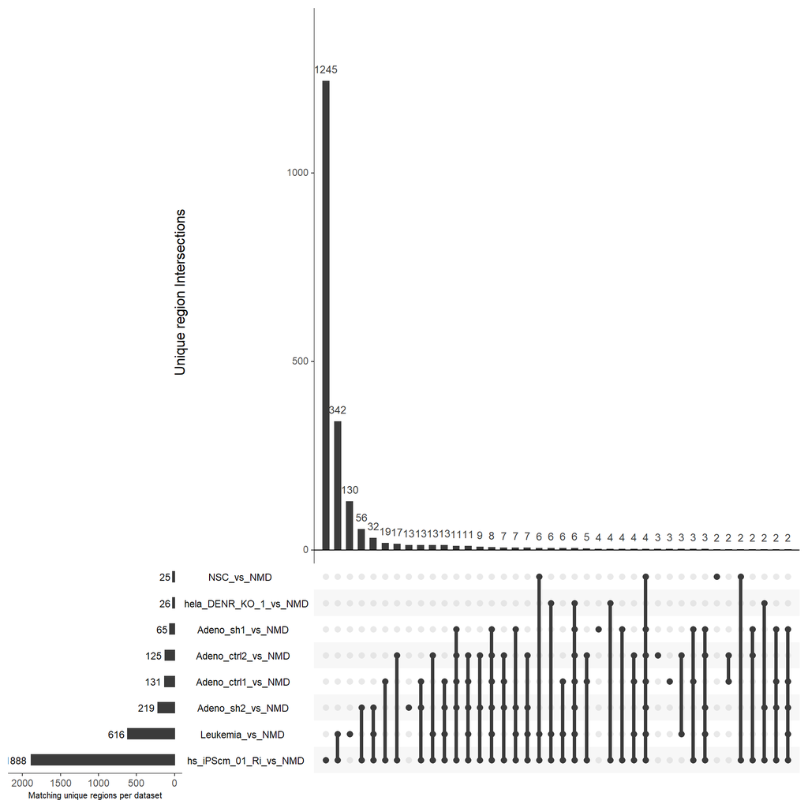

### The following shows the number of ORFs validated by Ribo-Seq and mass spectrometry and gives a list of these ORFs accordingly.

Number of ORFs validated by Ribo-seq and mass spectrometry

|  | Overlap |
| --- | --- |
| Adeno_ctrl1_vs_NMD | 9 |
| Adeno_ctrl2_vs_NMD | 8 |
| Adeno_sh1_vs_NMD | 5 |
| Adeno_sh2_vs_NMD | 10 |
| Harr_vs_NMD | 0 |
| hs_iPScm_01_Ri_vs_NMD | 53 |
| RiboLace_vs_NMD | 0 |
| NSC_vs_NMD | 3 |
| hela_WT_vs_NMD | 3 |
| hela_DENR_KO_1_vs_NMD | 3 |
| hela_DENR_KO_2_vs_NMD | 3 |
| Leukemia_vs_NMD | 25 |
| LTM_rep1_vs_NMD | 0 |
| LTM_rep2_vs_NMD | 0 |

| Adeno_ctrl1_vs_NMD |
| --- |
| ENSG00000204628\|ENST00000504325:ORF-22960:231:1047 |
| ENSG00000204628\|ENST00000508682:ORF-17643:102:546 |
| ENSG00000186010\|ENST00000606722:ORF-29918:253:433 |
| ENSG00000138119\|ENST00000463743:ORF-12981:110:3533 |
| ENSG00000204628\|ENST00000508682:ORF-17645:862:1168 |
| ENSG00000090013\|ENST00000597870:ORF-38238:47:512 |
| ENSG00000204628\|ENST00000504325:ORF-22960:231:1047 |
| ENSG00000137054\|ENST00000442009:ORF-6201:100:526 |
| ENSG00000070087\|ENST00000498169:ORF-16750:256:424 |

| Adeno_ctrl2_vs_NMD |
| --- |
| ENSG00000204628\|ENST00000508682:ORF-17643:102:546 |
| ENSG00000186010\|ENST00000606722:ORF-29918:253:433 |
| ENSG00000204628\|ENST00000504325:ORF-22960:231:1047 |
| ENSG00000204628\|ENST00000504325:ORF-22960:231:1047 |
| ENSG00000204628\|ENST00000508682:ORF-17645:862:1168 |
| ENSG00000105755\|ENST00000594342:ORF-30245:248:644 |
| ENSG00000090013\|ENST00000597870:ORF-38238:47:512 |
| ENSG00000161888\|ENST00000423327:ORF-7289:315:738 |

| Adeno_sh1_vs_NMD |
| --- |
| ENSG00000204628\|ENST00000508682:ORF-17643:102:546 |
| ENSG00000204628\|ENST00000504325:ORF-22960:231:1047 |
| ENSG00000090013\|ENST00000597870:ORF-38238:47:512 |
| ENSG00000204628\|ENST00000508682:ORF-17645:862:1168 |
| ENSG00000186010\|ENST00000606722:ORF-29918:253:433 |

| Adeno_sh2_vs_NMD |
| --- |
| ENSG00000204628\|ENST00000508682:ORF-17643:102:546 |
| ENSG00000090013\|ENST00000597870:ORF-38238:47:512 |
| ENSG00000204628\|ENST00000504325:ORF-22960:231:1047 |
| ENSG00000204628\|ENST00000504325:ORF-22960:231:1047 |
| ENSG00000186010\|ENST00000606722:ORF-29918:253:433 |
| ENSG00000204628\|ENST00000508682:ORF-17645:862:1168 |
| ENSG00000161888\|ENST00000423327:ORF-7289:315:738 |
| ENSG00000075785\|ENST00000490093:ORF-8638:623:848 |
| ENSG00000070087\|ENST00000498169:ORF-16750:256:424 |
| ENSG00000018510\|ENST00000681032:ORF-42256:881:2123 |

| Harr_vs_NMD |
| --- |
| No Overlap |

| hs_iPScm_01_Ri_vs_NMD |
| --- |
| ENSG00000118194\|ENST00000663843:ORF-49794:147:315 |
| ENSG00000186010\|ENST00000606722:ORF-29918:253:433 |
| ENSG00000204628\|ENST00000504325:ORF-22960:231:1047 |
| ENSG00000204628\|ENST00000508682:ORF-17645:862:1168 |
| ENSG00000133872\|ENST00000518174:ORF-16479:279:1191 |
| ENSG00000204628\|ENST00000508682:ORF-17643:102:546 |
| ENSG00000125821\|ENST00000647441:ORF-29606:568:808 |
| ENSG00000204628\|ENST00000504325:ORF-22960:231:1047 |
| ENSG00000140416\|ENST00000558347:ORF-15384:554:812 |
| ENSG00000075785\|ENST00000490093:ORF-8638:623:848 |
| ENSG00000133872\|ENST00000520303:ORF-25484:541:1045 |
| ENSG00000161888\|ENST00000423327:ORF-7289:315:738 |
| ENSG00000104408\|ENST00000676892:ORF-46333:1276:1438 |
| ENSG00000143549\|ENST00000341485:ORF-1634:84:828 |
| ENSG00000189182\|ENST00000553168:ORF-18389:29:776 |
| ENSG00000168894\|ENST00000443647:ORF-12134:8:245 |
| ENSG00000168894\|ENST00000443647:ORF-12134:8:245 |
| ENSG00000104408\|ENST00000522445:ORF-17812:318:1377 |
| ENSG00000143549\|ENST00000341485:ORF-1634:84:828 |
| ENSG00000104408\|ENST00000678004:ORF-52275:231:1236 |
| ENSG00000140365\|ENST00000562610:ORF-25979:365:584 |
| ENSG00000130414\|ENST00000678832:ORF-41652:470:1022 |
| ENSG00000130414\|ENST00000678832:ORF-41652:470:1022 |
| ENSG00000070087\|ENST00000498169:ORF-16750:256:424 |
| ENSG00000138119\|ENST00000463743:ORF-12981:110:3533 |
| ENSG00000151348\|ENST00000684124:ORF-52568:159:1542 |
| ENSG00000018510\|ENST00000680893:ORF-52176:769:2011 |
| ENSG00000171503\|ENST00000684552:ORF-47501:4004:4589 |
| ENSG00000171503\|ENST00000684296:ORF-48095:1424:2105 |
| ENSG00000151348\|ENST00000684124:ORF-52568:159:1542 |
| ENSG00000018510\|ENST00000681032:ORF-42256:881:2123 |
| ENSG00000090013\|ENST00000597870:ORF-38238:47:512 |
| ENSG00000018510\|ENST00000681565:ORF-48662:1200:2166 |
| ENSG00000075151\|ENST00000681717:ORF-51581:437:5162 |
| ENSG00000143549\|ENST00000341485:ORF-1634:84:828 |
| ENSG00000018510\|ENST00000681752:ORF-42320:548:2159 |
| ENSG00000097021\|ENST00000377860:ORF-3601:58:910 |
| ENSG00000132199\|ENST00000581475:ORF-28700:565:1354 |
| ENSG00000137054\|ENST00000442009:ORF-6201:100:526 |
| ENSG00000129103\|ENST00000452216:ORF-13164:154:796 |
| ENSG00000171503\|ENST00000684675:ORF-52821:1405:2086 |
| ENSG00000151348\|ENST00000684039:ORF-46274:205:1543 |
| ENSG00000105755\|ENST00000594342:ORF-30245:248:644 |
| ENSG00000133392\|ENST00000652121:ORF-54739:104:2012 |
| ENSG00000147687\|ENST00000523214:ORF-19731:628:1048 |
| ENSG00000129103\|ENST00000438133:ORF-6570:552:714 |
| ENSG00000129103\|ENST00000423763:ORF-6040:604:766 |
| ENSG00000101901\|ENST00000489033:ORF-11536:303:567 |
| ENSG00000171503\|ENST00000683448:ORF-50984:975:1656 |
| ENSG00000171503\|ENST00000683079:ORF-42489:1260:1941 |
| ENSG00000225830\|ENST00000679596:ORF-49141:640:3148 |
| ENSG00000099968\|ENST00000498133:ORF-18937:196:433 |
| ENSG00000197102\|ENST00000684561:ORF-44450:8765:14165 |

| RiboLace_vs_NMD |
| --- |
| No Overlap |

| NSC_vs_NMD |
| --- |
| ENSG00000097021\|ENST00000377860:ORF-3601:58:910 |
| ENSG00000143549\|ENST00000341485:ORF-1634:84:828 |
| ENSG00000204628\|ENST00000504325:ORF-22960:231:1047 |

| hela_WT_vs_NMD |
| --- |
| ENSG00000204628\|ENST00000508682:ORF-17643:102:546 |
| ENSG00000143549\|ENST00000341485:ORF-1634:84:828 |
| ENSG00000186010\|ENST00000606722:ORF-29918:253:433 |

| hela_DENR_KO_1_vs_NMD |
| --- |
| ENSG00000186010\|ENST00000606722:ORF-29918:253:433 |
| ENSG00000137054\|ENST00000442009:ORF-6201:100:526 |
| ENSG00000143549\|ENST00000341485:ORF-1634:84:828 |

| hela_DENR_KO_2_vs_NMD |
| --- |
| ENSG00000186010\|ENST00000606722:ORF-29918:253:433 |
| ENSG00000018510\|ENST00000681032:ORF-42256:881:2123 |
| ENSG00000143549\|ENST00000341485:ORF-1634:84:828 |

| Leukemia_vs_NMD |
| --- |
| ENSG00000204628\|ENST00000504325:ORF-22960:231:1047 |
| ENSG00000204628\|ENST00000508682:ORF-17643:102:546 |
| ENSG00000204628\|ENST00000504325:ORF-22960:231:1047 |
| ENSG00000097021\|ENST00000377860:ORF-3601:58:910 |
| ENSG00000186010\|ENST00000606722:ORF-29918:253:433 |
| ENSG00000204628\|ENST00000508682:ORF-17645:862:1168 |
| ENSG00000133872\|ENST00000518174:ORF-16479:279:1191 |
| ENSG00000143549\|ENST00000341485:ORF-1634:84:828 |
| ENSG00000104408\|ENST00000522445:ORF-17812:318:1377 |
| ENSG00000104408\|ENST00000678004:ORF-52275:231:1236 |
| ENSG00000143549\|ENST00000341485:ORF-1634:84:828 |
| ENSG00000133872\|ENST00000520303:ORF-25484:541:1045 |
| ENSG00000105755\|ENST00000594342:ORF-30245:248:644 |
| ENSG00000140365\|ENST00000562610:ORF-25979:365:584 |
| ENSG00000075785\|ENST00000490093:ORF-8638:623:848 |
| ENSG00000129103\|ENST00000452216:ORF-13164:154:796 |
| ENSG00000125821\|ENST00000647441:ORF-29606:568:808 |
| ENSG00000075151\|ENST00000681717:ORF-51581:437:5162 |
| ENSG00000151348\|ENST00000684124:ORF-52568:159:1542 |
| ENSG00000145907\|ENST00000676644:ORF-52261:129:300 |
| ENSG00000143549\|ENST00000341485:ORF-1634:84:828 |
| ENSG00000137054\|ENST00000442009:ORF-6201:100:526 |
| ENSG00000093217\|ENST00000424034:ORF-5586:321:1521 |
| ENSG00000161888\|ENST00000423327:ORF-7289:315:738 |
| ENSG00000168894\|ENST00000443647:ORF-12134:8:245 |

| LTM_rep1_vs_NMD |
| --- |
| No Overlap |

| LTM_rep2_vs_NMD |
| --- |
| No Overlap |

### The following shows the overlapp between the Ribo-seq and MS validated unique-Regions

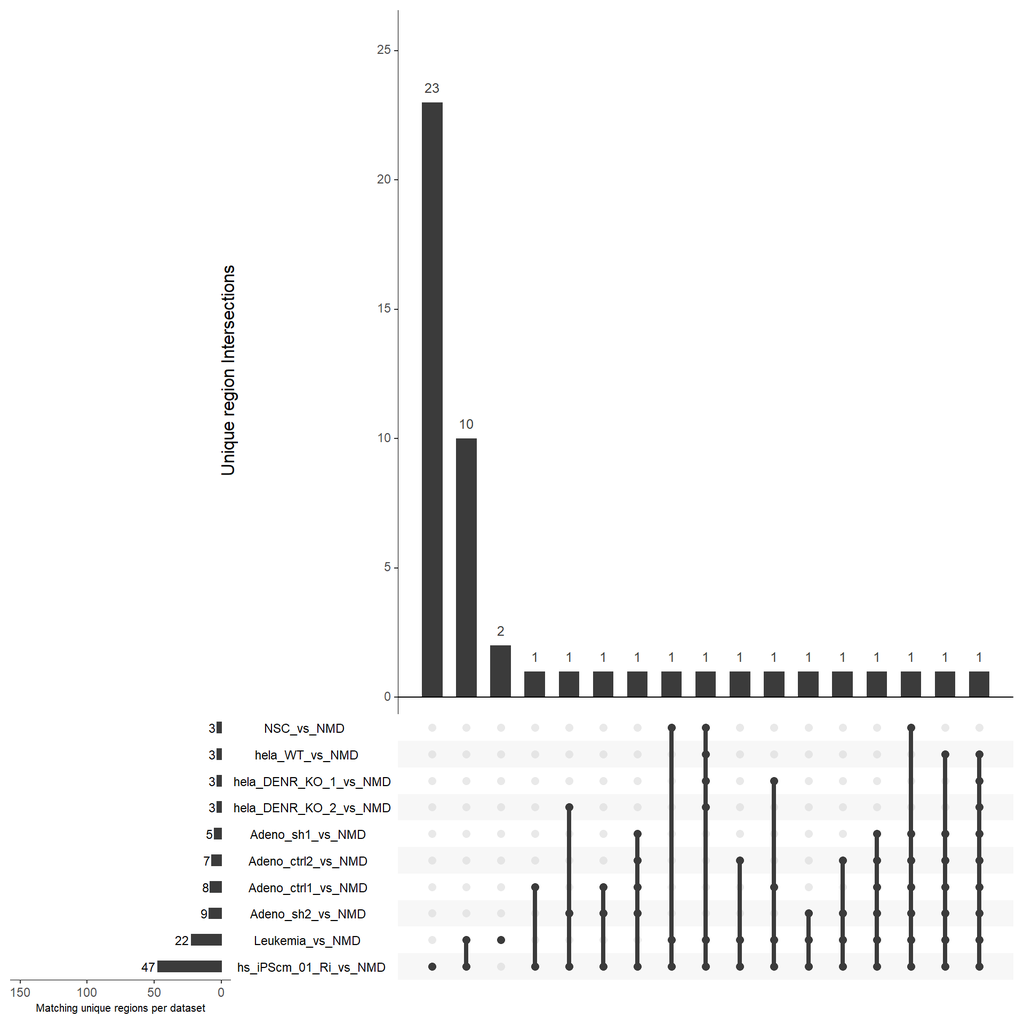

## Alignment against RI transcripts

The thresholds for each dataset are determined by calculating the average relative read count (number of reads per bp) aligning to randomly selected regions of the 3’UTR-regions of the longest isoforms of all coding transcripts.

Thresholds for each dataset

|  | Threshold |
| --- | --- |
| Adeno_ctrl1_vs_RI | 0.0000302 |
| Adeno_ctrl2_vs_RI | 0.0000339 |
| Adeno_sh1_vs_RI | 0.0142627 |
| Adeno_sh2_vs_RI | 0.0048344 |
| Harr_vs_RI | 0.0165270 |
| hs_iPScm_01_Ri_vs_RI | 0.0407032 |
| RiboLace_vs_RI | 0.0000190 |
| NSC_vs_RI | 0.0000816 |
| hela_WT_vs_RI | 0.0000425 |
| hela_DENR_KO_1_vs_RI | 0.0000517 |
| hela_DENR_KO_2_vs_RI | 0.0000332 |
| Leukemia_vs_RI | 0.3192107 |
| LTM_rep1_vs_RI | 0.0092162 |
| LTM_rep2_vs_RI | 0.0252307 |

Average relative counts of non-unique regions for each dataset

|  | Average relative count |
| --- | --- |
| Adeno_ctrl1_vs_RI | 0.0039464 |
| Adeno_ctrl2_vs_RI | 0.0042469 |
| Adeno_sh1_vs_RI | 0.0024790 |
| Adeno_sh2_vs_RI | 0.0072617 |
| Harr_vs_RI | 0.0029788 |
| hs_iPScm_01_Ri_vs_RI | 0.1246322 |
| RiboLace_vs_RI | 0.0003653 |
| NSC_vs_RI | 0.0003027 |
| hela_WT_vs_RI | 0.0004753 |
| hela_DENR_KO_1_vs_RI | 0.0006345 |
| hela_DENR_KO_2_vs_RI | 0.0004311 |
| Leukemia_vs_RI | 0.2650103 |
| LTM_rep1_vs_RI | 0.0014133 |
| LTM_rep2_vs_RI | 0.0005930 |

Regions above the threshold

|  | Number of unique regions with relative count >= Threshold |
| --- | --- |
| Adeno_ctrl1_vs_RI | 281 |
| Adeno_ctrl2_vs_RI | 261 |
| Adeno_sh1_vs_RI | 115 |
| Adeno_sh2_vs_RI | 423 |
| Harr_vs_RI | 23 |
| hs_iPScm_01_Ri_vs_RI | 2174 |
| RiboLace_vs_RI | 1 |
| NSC_vs_RI | 31 |
| hela_WT_vs_RI | 48 |
| hela_DENR_KO_1_vs_RI | 62 |
| hela_DENR_KO_2_vs_RI | 46 |
| Leukemia_vs_RI | 725 |
| LTM_rep1_vs_RI | 27 |
| LTM_rep2_vs_RI | 20 |

### The following table shows the top five unique regions with a relative count above the threshold (if available).

Adeno_ctrl1_vs_RI

| ID | start | stop | read_count | relative_count |
| --- | --- | --- | --- | --- |
| ENSG00000111640\|ENST00000466525:ORF-10266:293:566 | 205 | 273 | 102 | 1.500000 |
| ENSG00000111640\|ENST00000466525:ORF-10266:293:566 | 0 | 113 | 153 | 1.353980 |
| ENSG00000111640\|ENST00000466525:ORF-10267:845:1553 | 32 | 224 | 253 | 1.317710 |
| ENSG00000120708\|ENST00000506699:ORF-31150:942:1227 | 250 | 285 | 38 | 1.085710 |
| ENSG00000184009\|ENST00000574671:ORF-63181:124:565 | 363 | 441 | 73 | 0.935897 |

Adeno_ctrl2_vs_RI

| ID | start | stop | read_count | relative_count |
| --- | --- | --- | --- | --- |
| ENSG00000111640\|ENST00000466525:ORF-10266:293:566 | 205 | 273 | 84 | 1.235290 |
| ENSG00000111640\|ENST00000466525:ORF-10267:845:1553 | 32 | 224 | 233 | 1.213540 |
| ENSG00000111640\|ENST00000466525:ORF-10266:293:566 | 0 | 113 | 136 | 1.203540 |
| ENSG00000120708\|ENST00000506699:ORF-31150:942:1227 | 250 | 285 | 28 | 0.800000 |
| ENSG00000075415\|ENST00000546766:ORF-23596:90:459 | 157 | 369 | 164 | 0.773585 |

Adeno_sh1_vs_RI

| ID | start | stop | read_count | relative_count |
| --- | --- | --- | --- | --- |
| ENSG00000198467\|ENST00000471212:ORF-6420:751:1108 | 304 | 357 | 30 | 0.566038 |
| ENSG00000111640\|ENST00000466525:ORF-10266:293:566 | 205 | 273 | 34 | 0.500000 |
| ENSG00000184009\|ENST00000679410:ORF-69946:124:985 | 805 | 861 | 26 | 0.464286 |
| ENSG00000111640\|ENST00000466525:ORF-10266:293:566 | 0 | 113 | 48 | 0.424779 |
| ENSG00000111640\|ENST00000466525:ORF-10267:845:1553 | 32 | 224 | 76 | 0.395833 |

Adeno_sh2_vs_RI

| ID | start | stop | read_count | relative_count |
| --- | --- | --- | --- | --- |
| ENSG00000111640\|ENST00000466525:ORF-10266:293:566 | 0 | 113 | 249 | 2.20354 |
| ENSG00000111640\|ENST00000466525:ORF-10267:845:1553 | 32 | 224 | 391 | 2.03646 |
| ENSG00000111640\|ENST00000466525:ORF-10266:293:566 | 205 | 273 | 138 | 2.02941 |
| ENSG00000120708\|ENST00000506699:ORF-31150:942:1227 | 250 | 285 | 42 | 1.20000 |
| ENSG00000198467\|ENST00000471212:ORF-6420:751:1108 | 304 | 357 | 63 | 1.18868 |

Harr_vs_RI

| ID | start | stop | read_count | relative_count |
| --- | --- | --- | --- | --- |
| ENSG00000120071\|ENST00000573286:ORF-45408:3957:4422 | 267 | 465 | 762 | 3.848480 |
| ENSG00000172890\|ENST00000531236:ORF-29688:2626:3286 | 605 | 660 | 59 | 1.072730 |
| ENSG00000172932\|ENST00000512231:ORF-42800:1162:1417 | 31 | 255 | 216 | 0.964286 |
| ENSG00000172932\|ENST00000513750:ORF-36950:1162:1417 | 31 | 255 | 198 | 0.883929 |
| ENSG00000135931\|ENST00000684224:ORF-71885:2606:2885 | 0 | 26 | 21 | 0.807692 |

hs_iPScm_01_Ri_vs_RI

| ID | start | stop | read_count | relative_count |
| --- | --- | --- | --- | --- |
| ENSG00000140416\|ENST00000560975:ORF-40989:146:437 | 114 | 291 | 6039 | 34.1186 |
| ENSG00000173641\|ENST00000442459:ORF-2737:80:287 | 82 | 109 | 917 | 33.9630 |
| ENSG00000075624\|ENST00000462494:ORF-4711:84:642 | 363 | 558 | 6370 | 32.6667 |
| ENSG00000149925\|ENST00000564521:ORF-24202:93:480 | 327 | 387 | 1893 | 31.5500 |
| ENSG00000092841\|ENST00000548725:ORF-31381:294:570 | 95 | 186 | 1732 | 19.0330 |

RiboLace_vs_RI

| ID | start | stop | read_count | relative_count |
| --- | --- | --- | --- | --- |
| ENSG00000112146\|ENST00000474457:ORF-11252:1190:1832 | 562 | 642 | 2 | 0.025 |

NSC_vs_RI

| ID | start | stop | read_count | relative_count |
| --- | --- | --- | --- | --- |
| ENSG00000166794\|ENST00000561048:ORF-39762:33:417 | 344 | 384 | 12 | 0.3000000 |
| ENSG00000115053\|ENST00000676798:ORF-57490:1994:2771 | 746 | 777 | 4 | 0.1290320 |
| ENSG00000135486\|ENST00000679228:ORF-71241:59:272 | 136 | 213 | 7 | 0.0909091 |
| ENSG00000196365\|ENST00000587552:ORF-52719:388:1291 | 828 | 903 | 5 | 0.0666667 |
| ENSG00000164080\|ENST00000487093:ORF-15847:125:1496 | 1339 | 1371 | 2 | 0.0625000 |

hela_WT_vs_RI

| ID | start | stop | read_count | relative_count |
| --- | --- | --- | --- | --- |
| ENSG00000144381\|ENST00000461097:ORF-2906:38:515 | 429 | 477 | 7 | 0.1458330 |
| ENSG00000143549\|ENST00000469717:ORF-9873:92:353 | 0 | 66 | 6 | 0.0909091 |
| ENSG00000112306\|ENST00000484616:ORF-12666:82:316 | 132 | 234 | 9 | 0.0882353 |
| ENSG00000144381\|ENST00000476746:ORF-13011:1209:1404 | 40 | 195 | 13 | 0.0838710 |
| ENSG00000144381\|ENST00000461097:ORF-2907:2909:3104 | 40 | 195 | 12 | 0.0774194 |

hela_DENR_KO_1_vs_RI

| ID | start | stop | read_count | relative_count |
| --- | --- | --- | --- | --- |
| ENSG00000111640\|ENST00000466525:ORF-10266:293:566 | 205 | 273 | 9 | 0.1323530 |
| ENSG00000109971\|ENST00000532091:ORF-41314:1319:1574 | 179 | 255 | 9 | 0.1184210 |
| ENSG00000108298\|ENST00000577741:ORF-62424:28:295 | 240 | 267 | 3 | 0.1111110 |
| ENSG00000112306\|ENST00000484616:ORF-12666:82:316 | 132 | 234 | 10 | 0.0980392 |
| ENSG00000063177\|ENST00000552347:ORF-25822:643:952 | 0 | 65 | 5 | 0.0769231 |

hela_DENR_KO_2_vs_RI

| ID | start | stop | read_count | relative_count |
| --- | --- | --- | --- | --- |
| ENSG00000144381\|ENST00000461097:ORF-2906:38:515 | 429 | 477 | 6 | 0.1250000 |
| ENSG00000111640\|ENST00000466525:ORF-10266:293:566 | 205 | 273 | 6 | 0.0882353 |
| ENSG00000144381\|ENST00000461097:ORF-2907:2909:3104 | 40 | 195 | 11 | 0.0709677 |
| ENSG00000112306\|ENST00000484616:ORF-12666:82:316 | 132 | 234 | 7 | 0.0686275 |
| ENSG00000129351\|ENST00000587928:ORF-63293:1924:3058 | 1086 | 1134 | 3 | 0.0625000 |

Leukemia_vs_RI

| ID | start | stop | read_count | relative_count |
| --- | --- | --- | --- | --- |
| ENSG00000142534\|ENST00000600027:ORF-45572:92:410 | 224 | 318 | 4103 | 43.6489 |
| ENSG00000112306\|ENST00000484616:ORF-12666:82:316 | 132 | 234 | 2260 | 22.1569 |
| ENSG00000108107\|ENST00000426763:ORF-2034:1529:1736 | 39 | 207 | 2985 | 17.7679 |
| ENSG00000111640\|ENST00000466525:ORF-10267:845:1553 | 32 | 224 | 2576 | 13.4167 |
| ENSG00000156508\|ENST00000488500:ORF-22269:62:710 | 621 | 648 | 354 | 13.1111 |

LTM_rep1_vs_RI

| ID | start | stop | read_count | relative_count |
| --- | --- | --- | --- | --- |
| ENSG00000120071\|ENST00000573286:ORF-45408:3957:4422 | 267 | 465 | 1148 | 5.797980 |
| ENSG00000105819\|ENST00000469560:ORF-5794:1066:1249 | 87 | 163 | 89 | 1.171050 |
| ENSG00000172932\|ENST00000512231:ORF-42800:1162:1417 | 31 | 255 | 218 | 0.973214 |
| ENSG00000172932\|ENST00000513750:ORF-36950:1162:1417 | 31 | 255 | 202 | 0.901786 |
| ENSG00000172890\|ENST00000531236:ORF-29688:2626:3286 | 605 | 660 | 47 | 0.854545 |

LTM_rep2_vs_RI

| ID | start | stop | read_count | relative_count |
| --- | --- | --- | --- | --- |
| ENSG00000120071\|ENST00000573286:ORF-45408:3957:4422 | 267 | 465 | 583 | 2.944440 |
| ENSG00000172932\|ENST00000512231:ORF-42800:1162:1417 | 31 | 255 | 189 | 0.843750 |
| ENSG00000172932\|ENST00000513750:ORF-36950:1162:1417 | 31 | 255 | 186 | 0.830357 |
| ENSG00000105819\|ENST00000469560:ORF-5794:1066:1249 | 87 | 163 | 54 | 0.710526 |
| ENSG00000172890\|ENST00000531236:ORF-29688:2626:3286 | 605 | 660 | 30 | 0.545455 |

### The following plot shows how many unique regions are expressed in which dataset and how those overlap with the other data sets.

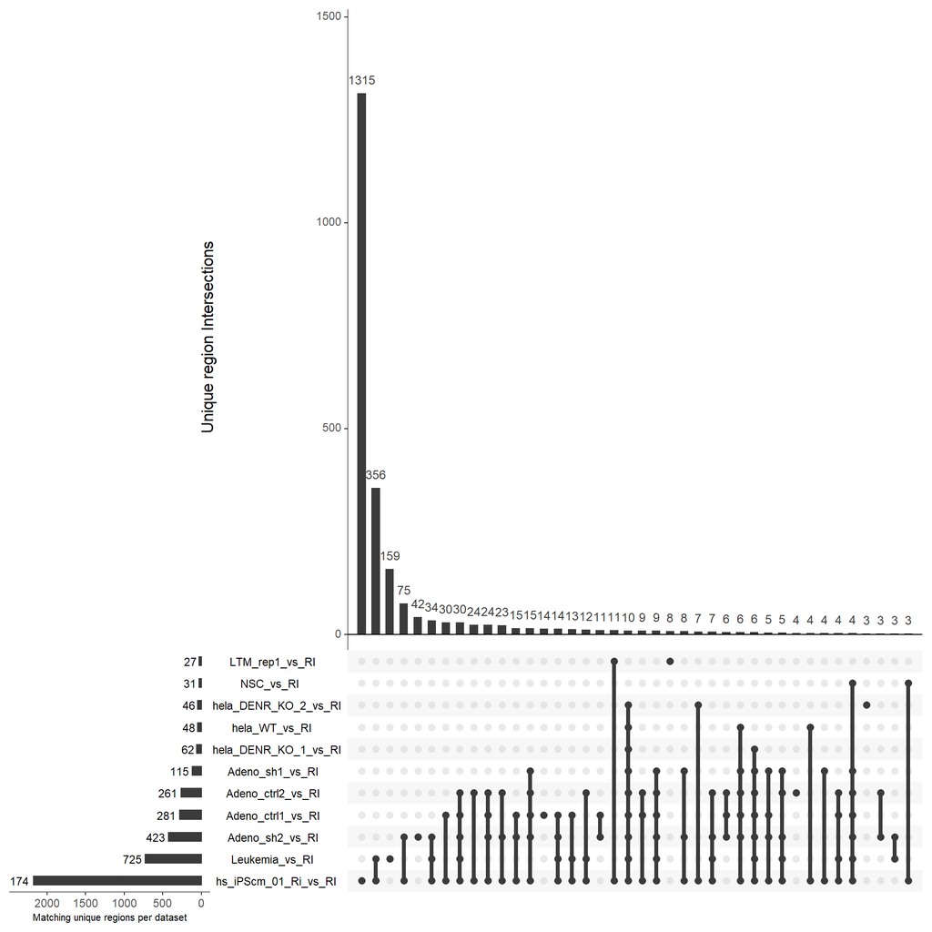